# README

2023-01-20

# Purpose

The purpose of this README is to provide sanitized code for my Advanced Financial Econometrics 871 project. The purpose of the project is to investigate time-varying conditional correlations between FTSE/JSE-listed property securities and the broader FTSE/JSE assets by adopting the Dynamic Conditional Correlation (DCC) Multivariate Generalized Autoregressive Conditional Heteroskedasticity (MV GARCH) modelling procedure. See the PDF document in the repository for the final project.

The DCC MV-GARCH model’s results suggest that, on aggregate, the comovement between PROP, SWIX(J433), and SMLC(J202) is amplified during periods of heightened global economic uncertainty. Although the PROP index is the most volatile of the indexes and the SMLC(J202) index the least volatile, it exhibits a substantially lower time-varying conditional correlation with the SWIX(J433) index compared to the SMLC(J202) index. However, since 2016, this difference has shrunk marginally. On the other hand, the dynamic conditional correlation between the SMLC(J202) and SWIX(J433) indexes is the highest and the more stable among the three index pairs considered. These results infer that an investor holding large proportions of SWIX(J433) constituents will achieve superior portfolio diversification in purchasing listed property compared to SMLC(J202) constituents.

```r
pacman::p_load("MTS", "robustbase")
pacman::p_load("tidyverse", "devtools", "rugarch", "rmgarch",
    "forecast", "tbl2xts", "lubridate", "PerformanceAnalytics",
    "ggthemes")
```

# Data import

```r
T40 <- read_rds("data/data_from_exam/T40.rds") # There are 92 stocks in this tbl

RebDays <- read_rds("data/data_from_exam/Rebalance_days.rds")

Capped_SWIX <- read_rds("data/data_from_exam/Capped_SWIX.rds") # This is the Monthly Capped and Weighted Portf Returns for SWIX Index (J433)


## I separately load the data for the property index (PROP)

"C:/Users/tianc/Rproj/FinMetrics871_Project/19025831/data/Alsi_Returns.rds" |>  read_rds() -> df



# I first shrink the dataframe to include only what in needed

T40_a <- df |> select(date, Tickers, Return, Index_Name, J433, J200, J202) |>

    mutate(Tickers = gsub(" SJ Equity", "", Tickers))  # Remove clutter in Tickers names


T40_b <- T40 |> select(-Short.Name) |>

    mutate(Tickers = gsub(" SJ Equity", "", Tickers))  # Remove clutter in Tickers names
```

# Portfolio Construction and Sector Calculations

## SWIX, ALSI and PROP weighted portfolio cumulative returns

I first plot the ALSI and SWIX weighted portfolio cumulative returns, following some tedious data wrangling.

```r
# I generate a tbl calculating both Indexes weighted returns by hand

df_Port_ret <- T40_a |>

    mutate(J433 = coalesce(J433, 0)) |>

    mutate(J200 = coalesce(J200, 0)) |>

    mutate(J202 = coalesce(J202, 0)) |>

    mutate(ALSI_wret = Return*J200) |>

    mutate(SWIX_wret = Return*J433) |>

    mutate(SMALLCAP_wret = Return*J202) |>

    arrange(date) |>

    group_by(date) |>

    mutate(ALSI_pret = sum(ALSI_wret, na.rm = T)) |>

    mutate(SWIX_pret = sum(SWIX_wret, na.rm = T)) |>

    mutate(SMALLCAP_pret = sum(SMALLCAP_wret, na.rm = T))

df_Port_ret_B <-  T40_b |>

    mutate(J400 = coalesce(J400, 0)) |>

    mutate(J400 = coalesce(J400, 0)) |>

    mutate(ALSI_wret = Return*J200) |>

    mutate(SWIX_wret = Return*J400) |>

    arrange(date) |>

    group_by(date) |>

    mutate(ALSI_pret = sum(ALSI_wret)) |>

    mutate(SWIX_pret = sum(SWIX_wret))






## Calculate the weight of each property security on each day. And then calculate the UNCAPPED PORTFOLIO RETURN FOR THIS PROPERTY INDEX.

df_property <- df  |>
    filter(Sector %in% "Property") |>
    select(date, Tickers, Return, Index_Name, Market.Cap) |>
    group_by(date) |> mutate(weight = Market.Cap / sum(Market.Cap)) |>
    arrange(desc(weight)) |> ungroup() |>
    mutate(weight = coalesce(weight, 0)) |>
    mutate(PROP_wret = Return*weight) |>            # Here I calculate the weighted returns for each porperty security
    arrange(date) |>
    group_by(date) |>
    mutate(PROP_pret = sum(PROP_wret, na.rm = T)) |>
    mutate(Tickers = gsub(" SJ Equity", "", Tickers))



## NB ---> Test if the weights on each day sums to one:  df_property |> group_by(date) |> summarise(sum(weight)). (Success)


# And now I merge the (uncapped) weighted portfolio return

df_Port_ret1 <- df_Port_ret |> select(date, ALSI_pret, SWIX_pret, SMALLCAP_pret) |> unique() |> left_join(df_property |> select(date, PROP_pret) |> unique(), by  = "date" )
```

After double checking the weighted portfolio returns of the SWIX, ALSI, and PROP indexes using the Safe.Return function, I merge the ALSI and SWIX, and the PROP indexes weighted portfolio return tibbles.

```r
# Lets calculate the weighted portfolio daily return for ALSI and SWIX using Safe_Returns to verify my by hand calculation

Wghts_ALSI_xts <- T40_a |> select(date, Tickers , J200) |> tbl_xts(cols_to_xts = J200, spread_by = Tickers)

Wghts_SWIX_xts <- T40_a |> select(date, Tickers , J433) |> tbl_xts(cols_to_xts = J433, spread_by = Tickers)

Returns_xts <- T40_a |> select(date, Tickers , Return) |> tbl_xts(cols_to_xts = Return, spread_by = Tickers)

# Set NA's to null to use PA's Safe_returns.Portfolio command

Wghts_ALSI_xts[is.na(Wghts_ALSI_xts)] <- 0
Wghts_SWIX_xts[is.na(Wghts_SWIX_xts)] <- 0
Returns_xts[is.na(Returns_xts)] <- 0

# Now I calculate the weighed (uncapped) portfolio returns

Port_Ret_ALSI <- rmsfuns::Safe_Return.portfolio(R = Returns_xts, weights = Wghts_ALSI_xts, lag_weights = T) |>

                 xts_tbl() |> rename(ALSI_Ret = portfolio.returns)

Port_Ret_SWIX <- rmsfuns::Safe_Return.portfolio(R = Returns_xts, weights = Wghts_SWIX_xts, lag_weights = T) |>

                 xts_tbl() |> rename(SWIX_Ret = portfolio.returns)

# Now I combine the above two weighted portfolio returns

Merged_Port_Ret <- inner_join(Port_Ret_ALSI, Port_Ret_SWIX, by= "date") |> inner_join(df_property |> select(date, PROP_pret) |> unique(), by = "date")

# I verify that my by hand calc and the Safe_return calc is the same:
# df_Port_ret |> select(date, ALSI_pret, SWIX_pret) |> group_by(date, ALSI_pret, SWIX_pret ) |> summarise()
# Happy ---> They are the same
```

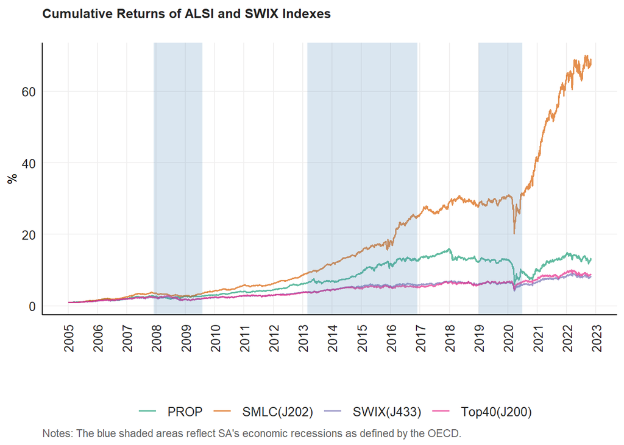

```r
# Now I proceed to calculate the Portfolios' cumulative return and plot it

Cum_ret <- df_Port_ret1 |> arrange(date) |> as_tibble() |>

    mutate(across(.cols = -date, .fns = ~cumprod(1 + .))) |>

    mutate(across(.cols = -date, .fns = ~./first(.))) |> # Start at 1

    rename("Top40(J200)" = ALSI_pret, "SWIX(J433)" = SWIX_pret, "SMLC(J202)" = SMALLCAP_pret ,PROP = PROP_pret) |>

    pivot_longer(cols=-date, names_to = "Index", values_to = "Cumret")

# And finally the plot

Indexes_Cum_ret_plot <-    Cum_ret |>

       ggplot() +

  geom_line(aes(date, Cumret , color = Index), size = 0.6, alpha = 0.7) +



    annotate("rect", xmin = lubridate::ymd("20130301"), xmax = lubridate::ymd("20161201"), ymin = -Inf, ymax = Inf,alpha = .2, fill='steelblue', alpha= 0.05) +

     annotate("rect", xmin = lubridate::ymd("20071201"), xmax = lubridate::ymd("20090801"), ymin = -Inf, ymax = Inf,alpha = .2, fill='steelblue', alpha= 0.05) +
     annotate("rect", xmin = lubridate::ymd("20190101"), xmax = lubridate::ymd("20200701"), ymin = -Inf, ymax = Inf,alpha = .2, fill='steelblue', alpha= 0.05) +

   fmxdat::theme_fmx(title.size = fmxdat::ggpts(30),
                    subtitle.size = fmxdat::ggpts(0),
                    caption.size = fmxdat::ggpts(25),
                    CustomCaption = T) +

  fmxdat::fmx_cols() +

  labs(x = "", y = "%", caption = "Notes: The blue shaded areas reflect SA's economic recessions as defined by the OECD.",
       title = "Cumulative Returns of ALSI and SWIX Indexes",
       subtitle = "")

# Finplot for finishing touches:

fmxdat::finplot(Indexes_Cum_ret_plot, x.vert = T, x.date.type = "%Y", x.date.dist = "1 year", darkcol = T)
```

From the plot above, the cumulative weighted returns for the ALSI and SWIX indexes are strickingly similar, however, since the onset of COVID-19, the ALSI has achieved higher returns.

## Weighted return contribition of each sector

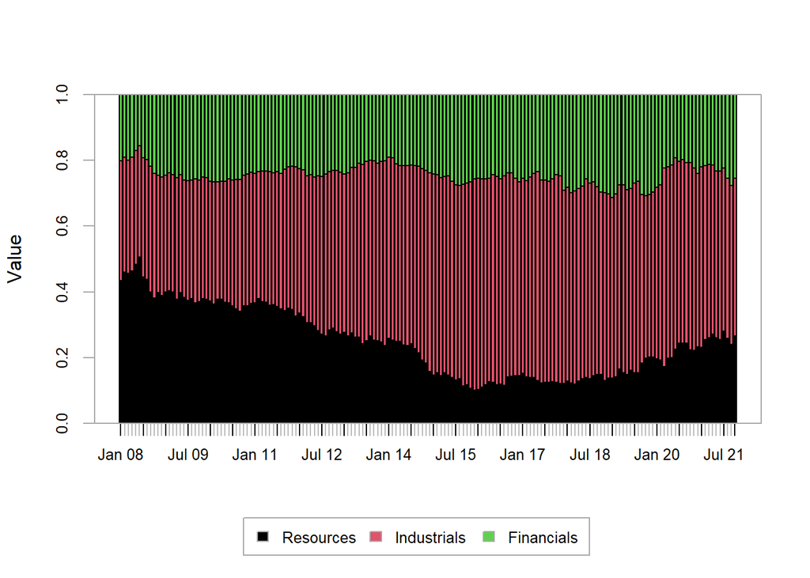

```r
# Calculated the weighted contribution of each sector by summing the individual security weights over Financials, Industrials, and Resources.

df_Port_ret_final <- df_Port_ret_B |> arrange(date) |>

    group_by(date, Sector) |>       # Group by Market Cap to calc each category's contr to wieghted portf return

    mutate(ALSI_wght_sector = coalesce(J400, 0)) |> # Make NA's 0 to use PA later

    mutate(SWIX_wght_sector = coalesce(J200, 0)) |>

    mutate(ALSI_wret = coalesce(ALSI_wret, 0)) |>

    mutate(SWIX_wret = coalesce(SWIX_wret, 0)) |>

    mutate(ALSI_ret_sector = sum(ALSI_wret, na.rm = T)) |>  # The weight-contribution of each sector on each day

    mutate(SWIX_ret_sector = sum(SWIX_wret, na.rm = T)) |>

    mutate(ALSI_wght_sector = sum(J400, na.rm = T)) |>  # The weighted return contribution of each sector on each day

    mutate(SWIX_wght_sector = sum(J200, na.rm = T)) |>

    ungroup()

ALSI_wght_sector <-  df_Port_ret_final |> select(date, Sector ,ALSI_wght_sector) |> group_by(Sector) |> unique() |>
    tbl_xts(cols_to_xts = ALSI_wght_sector, spread_by = Sector)

SWIX_wght_sector <- df_Port_ret_final |> select(date, Sector ,SWIX_wght_sector) |> group_by(Sector) |> unique() |>
    tbl_xts(cols_to_xts = SWIX_wght_sector, spread_by = Sector)

ALSI_ret_sector <- df_Port_ret_final |> select(date, Sector ,ALSI_ret_sector) |> group_by(Sector) |> unique() |>
    tbl_xts(cols_to_xts = ALSI_ret_sector, spread_by = Sector)

SWIX_ret_sector <- df_Port_ret_final |> select(date, Sector ,SWIX_ret_sector) |> group_by(Sector) |> unique() |>
    tbl_xts(cols_to_xts = SWIX_ret_sector, spread_by = Sector)



 ALSI_RetPort_sector <-
      rmsfuns::Safe_Return.portfolio(ALSI_ret_sector,

                       weights = ALSI_wght_sector, lag_weights = TRUE,

                       verbose = TRUE, contribution = TRUE,

                       value = 1000, geometric = TRUE)

 SWIX_RetPort_sector <-
      rmsfuns::Safe_Return.portfolio(SWIX_ret_sector,

                       weights = SWIX_wght_sector, lag_weights = TRUE,

                       verbose = TRUE, contribution = TRUE,

                       value = 1000, geometric = TRUE)








 ALSI_RetPort_sector$BOP.Weight  %>% .[endpoints(.,'months')] %>% chart.StackedBar()
```

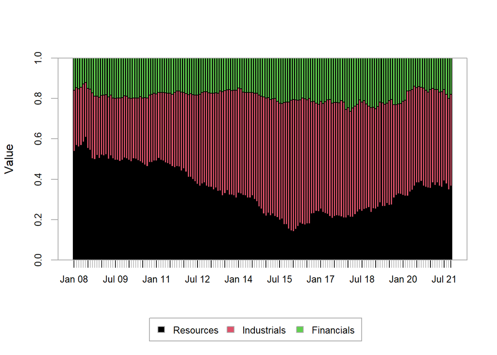

```r
  SWIX_RetPort_sector$BOP.Weight  %>% .[endpoints(.,'months')] %>% chart.StackedBar()
```

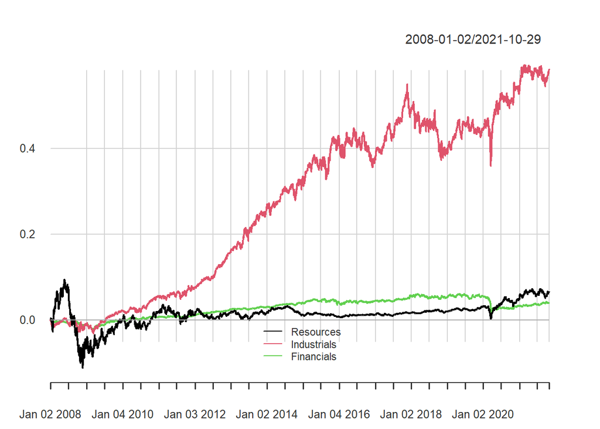

```r
  ALSI_RetPort_sector$contribution |> chart.CumReturns(legend.loc = "bottom")
```

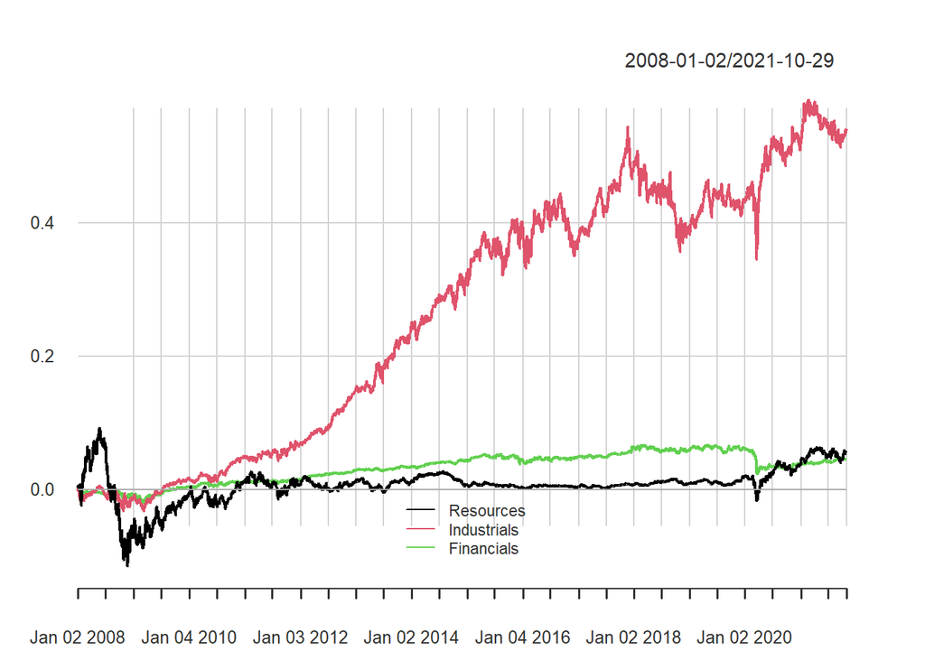

```r
  SWIX_RetPort_sector$contribution |> chart.CumReturns(legend.loc = "bottom")
```

Pull the rebalance days,

```r
# I firt pull the effective rebalance dates

Rebalance_Days <-RebDays |> filter(Date_Type %in% c("Effective Date")) |> pull(date)

# And now for both Indexes I create a capped weights tbl for rebalancing purposes

rebalance_col_ALSI <- df_Port_ret |>

    filter(date %in% Rebalance_Days) |>

    select(date, Tickers, J200) |>

    rename(weight = J200) |>

    mutate(RebalanceTime = format(date, "%Y_%b")) |>

    mutate(weight= coalesce(weight, 0))

 rebalance_col_SWIX <- df_Port_ret |>

    filter(date %in% Rebalance_Days) |>

    select(date, Tickers, J433) |>

     rename(weight = J433) |>

     mutate(RebalanceTime = format(date, "%Y_%b")) |>

      mutate(weight= coalesce(weight, 0))

## For SMALL CAPS

 rebalance_col_SMALLCAP <- df_Port_ret |>

    filter(date %in% Rebalance_Days) |>

    select(date, Tickers, J202) |>

     rename(weight = J202) |>

     mutate(RebalanceTime = format(date, "%Y_%b")) |>

      mutate(weight= coalesce(weight, 0))


## And for the df_property

  rebalance_col_PROP <- df_property |>

    filter(date %in% Rebalance_Days) |>

    select(date, Tickers, weight) |>

     mutate(RebalanceTime = format(date, "%Y_%b")) |>

      mutate(weight= coalesce(weight, 0))
```

```r
###### This function applies a capping on the weights. #########

Proportional_Cap_Foo <- function(df_Cons, W_Cap = 0.08){

  # Let's require a specific form from the user... Alerting when it does not adhere this form
  if( !"weight" %in% names(df_Cons)) stop("... for Calc capping to work, provide weight column called 'weight'")

  if( !"date" %in% names(df_Cons)) stop("... for Calc capping to work, provide date column called 'date'")

  if( !"Tickers" %in% names(df_Cons)) stop("... for Calc capping to work, provide id column called 'Tickers'")

  # First identify the cap breachers...
  Breachers <-
    df_Cons %>% filter(weight > W_Cap) %>% pull(Tickers)

  # Now keep track of breachers, and add to it to ensure they remain at 10%:
  if(length(Breachers) > 0) {

    while( df_Cons %>% filter(weight > W_Cap) %>% nrow() > 0 ) {


      df_Cons <-

        bind_rows(

          df_Cons %>% filter(Tickers %in% Breachers) %>% mutate(weight = W_Cap),

          df_Cons %>% filter(!Tickers %in% Breachers) %>%
            mutate(weight = (weight / sum(weight, na.rm=T)) * (1-length(Breachers)*W_Cap) )

        )

      Breachers <- c(Breachers, df_Cons %>% filter(weight > W_Cap) %>% pull(Tickers))

    }

    if( sum(df_Cons$weight, na.rm=T) > 1.001 | sum(df_Cons$weight, na.rm=T) < 0.999 | max(df_Cons$weight, na.rm = T) > W_Cap) {

      stop( glue::glue("For the Generic weight trimming function used: the weight trimming causes non unit
      summation of weights for date: {unique(df_Cons$date)}...\n
      The restriction could be too low or some dates have extreme concentrations...") )

    }

  } else {

  }

  df_Cons

  }


# Now, to map this across all the dates, I purrr::map_df
Capped_ALSI_10 <-

    rebalance_col_ALSI |>

    group_split(RebalanceTime) |>

    map_df(~Proportional_Cap_Foo(., W_Cap = 0.1) ) |>  select(-RebalanceTime)

# Now I do the same for a 6% cap:

Capped_ALSI_6 <-

    rebalance_col_ALSI |>

    group_split(RebalanceTime) |>

    map_df(~Proportional_Cap_Foo(., W_Cap = 0.06) ) |>  select(-RebalanceTime)

Capped_SWIX_10 <-

    rebalance_col_ALSI |>

    group_split(RebalanceTime) |>

    map_df(~Proportional_Cap_Foo(., W_Cap = 0.1) ) |>  select(-RebalanceTime)

Capped_SWIX_6 <-

    rebalance_col_ALSI |>

    group_split(RebalanceTime) |>

    map_df(~Proportional_Cap_Foo(., W_Cap = 0.06) ) |>  select(-RebalanceTime)


Capped_PROP_10 <-

    rebalance_col_PROP |>

    group_split(RebalanceTime) |>

    map_df(~Proportional_Cap_Foo(., W_Cap = 0.15) ) |>  select(-RebalanceTime)


Capped_SMALLCAP_10 <-

    rebalance_col_SMALLCAP |>

    group_split(RebalanceTime) |>

    map_df(~Proportional_Cap_Foo(., W_Cap = 0.1) ) |>  select(-RebalanceTime)



# # Testing if the max weight is correct for all 4 tbl above

Capped_ALSI_10 %>% pull(weight) %>% max(.)
```

```
## [1] 0.1
```

```r
Capped_ALSI_6 %>% pull(weight) %>% max(.)
```

```
## [1] 0.06
```

```r
Capped_SWIX_10 %>% pull(weight) %>% max(.)
```

```
## [1] 0.1
```

```r
Capped_SWIX_6 %>% pull(weight) %>% max(.) # Success!!
```

```
## [1] 0.06
```

```r
Capped_PROP_10 %>% pull(weight) %>% max(.)
```

```
## [1] 0.15
```

## 6% and 10% Capped indexes weighted returns

I now analyse the impact different capping levels would have had on both the SWIX and ALSI (6% and 10%).

```r
####For ALSI capped at 10%#####

wghts_ALSI_10 <-
  Capped_ALSI_10 %>%
  tbl_xts(cols_to_xts = weight, spread_by = Tickers)

ret_ALSI_10 <-
  df_Port_ret %>%

  filter(Tickers %in% unique(Capped_ALSI_10$Tickers) ) %>%

  tbl_xts(cols_to_xts = Return, spread_by = Tickers)

wghts_ALSI_10[is.na(wghts_ALSI_10)] <- 0

ret_ALSI_10[is.na(ret_ALSI_10)] <- 0

ALSI_10_Idx <-
  rmsfuns::Safe_Return.portfolio(R = ret_ALSI_10, weights = wghts_ALSI_10, lag_weights = T) |>

  # Then I make it a tibble:
  xts_tbl() |>

  rename(ALSI_10_Idx = portfolio.returns)

####For ALSI capped at 6%#####

wghts_ALSI_6 <-
  Capped_ALSI_6 %>%
  tbl_xts(cols_to_xts = weight, spread_by = Tickers)

ret_ALSI_6 <-
  df_Port_ret %>%

  filter(Tickers %in% unique(Capped_ALSI_6$Tickers) ) %>%

  tbl_xts(cols_to_xts = Return, spread_by = Tickers)

wghts_ALSI_6[is.na(wghts_ALSI_6)] <- 0

ret_ALSI_6[is.na(ret_ALSI_6)] <- 0

ALSI_6_Idx <-
  rmsfuns::Safe_Return.portfolio(R = ret_ALSI_6, weights = wghts_ALSI_6, lag_weights = T) |>

  # Then I make it a tibble:
  xts_tbl() |>

  rename(ALSI_6_Idx = portfolio.returns)

####For SWIX capped at 10%#####

wghts_SWIX_10 <-
  Capped_SWIX_10 %>%
  tbl_xts(cols_to_xts = weight, spread_by = Tickers)

ret_SWIX_10 <-
  df_Port_ret %>%

  filter(Tickers %in% unique(Capped_SWIX_10$Tickers) ) %>%

  tbl_xts(cols_to_xts = Return, spread_by = Tickers)

wghts_SWIX_10[is.na(wghts_SWIX_10)] <- 0

ret_SWIX_10[is.na(ret_SWIX_10)] <- 0

SWIX_10_Idx <-
  rmsfuns::Safe_Return.portfolio(R = ret_SWIX_10, weights = wghts_SWIX_10, lag_weights = T) |>

  # Then I make it a tibble:
  xts_tbl() |>

  rename(SWIX_10_Idx = portfolio.returns)



####For SWIX capped at 6%#####

wghts_SWIX_6 <-
  Capped_SWIX_6 %>%
  tbl_xts(cols_to_xts = weight, spread_by = Tickers)

ret_SWIX_6 <-
  df_Port_ret %>%

  filter(Tickers %in% unique(Capped_SWIX_6$Tickers) ) %>%

  tbl_xts(cols_to_xts = Return, spread_by = Tickers)

wghts_SWIX_6[is.na(wghts_SWIX_6)] <- 0

ret_SWIX_6[is.na(ret_SWIX_6)] <- 0

SWIX_6_Idx <-
  rmsfuns::Safe_Return.portfolio(R = ret_SWIX_6, weights = wghts_SWIX_6, lag_weights = T) |>

  # Then I make it a tibble:
  xts_tbl() |>

  rename(SWIX_6_Idx = portfolio.returns)

##### For PROP capped at 10% #####

wghts_PROP_10 <-
  Capped_PROP_10 %>%
  tbl_xts(cols_to_xts = weight, spread_by = Tickers)

ret_PROP_10 <-
  df_Port_ret %>%

  filter(Tickers %in% unique(Capped_PROP_10$Tickers) ) %>%

  tbl_xts(cols_to_xts = Return, spread_by = Tickers)

wghts_PROP_10[is.na(wghts_PROP_10)] <- 0

ret_PROP_10[is.na(ret_PROP_10)] <- 0

PROP_10_Idx <-
  rmsfuns::Safe_Return.portfolio(R = ret_PROP_10, weights = wghts_PROP_10, lag_weights = T) |>

  # Then I make it a tibble:
  xts_tbl() |>

  rename(PROP_10_Idx = portfolio.returns)


### For J202 SMALLCAP capped at 10%##

wghts_SMALLCAP_10 <-
  Capped_SMALLCAP_10 %>%
  tbl_xts(cols_to_xts = weight, spread_by = Tickers)

ret_SMALLCAP_10 <-
  df_Port_ret %>%

  filter(Tickers %in% unique(Capped_SMALLCAP_10$Tickers) ) %>%

  tbl_xts(cols_to_xts = Return, spread_by = Tickers)

wghts_SMALLCAP_10[is.na(wghts_SMALLCAP_10)] <- 0

ret_SMALLCAP_10[is.na(ret_SMALLCAP_10)] <- 0

SMALLCAP_10_Idx <-
  rmsfuns::Safe_Return.portfolio(R = ret_SMALLCAP_10, weights = wghts_SMALLCAP_10, lag_weights = T) |>

  # Then I make it a tibble:
  xts_tbl() |>

  rename(SMALLCAP_10_Idx = portfolio.returns)
```

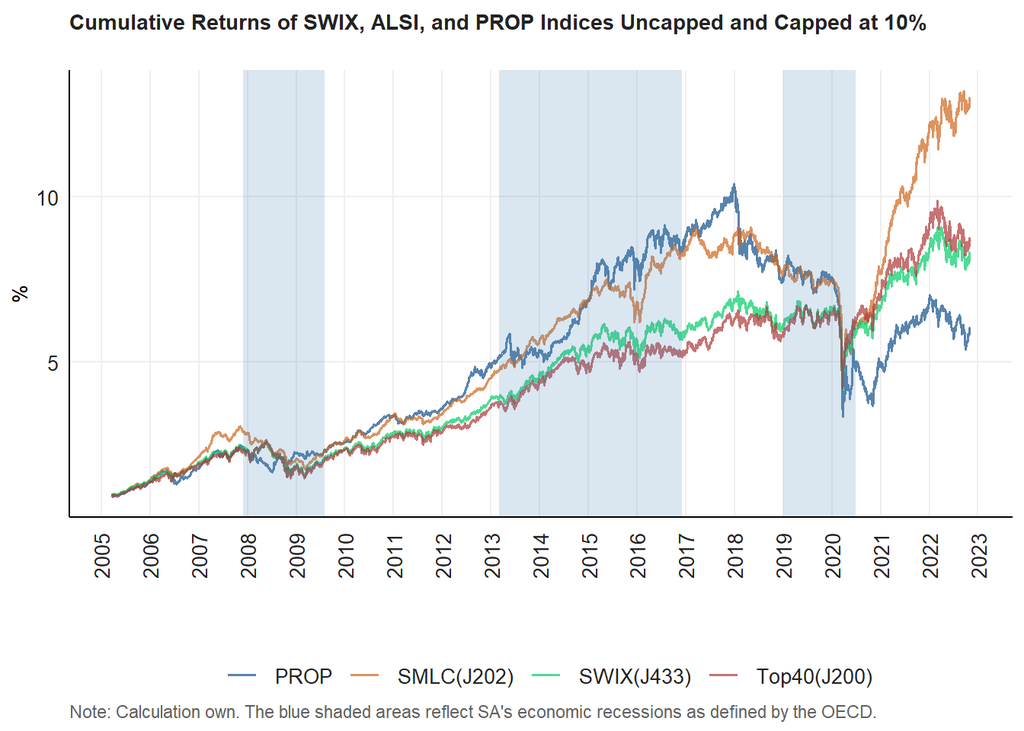

```r
Capped_df_final <- ALSI_10_Idx |>
    inner_join(PROP_10_Idx, by ="date") |>
    inner_join(SMALLCAP_10_Idx, by ="date") |>
    arrange(date) |>
    mutate(across(.cols = -date, .fns = ~cumprod(1+.))) |> # cumulative returns
    mutate(across(.cols = -date, .fns = ~./first(.))) |>   # Start at 1
    left_join(Cum_ret |> filter(Index %in% "SWIX(J433)") |> pivot_wider(names_from = "Index", values_from = "Cumret"), by = "date") |>



    rename("Top40(J200)" = ALSI_10_Idx , "PROP" = PROP_10_Idx , "SMLC(J202)" = SMALLCAP_10_Idx) |> # rename for clarity

    pivot_longer(cols = -date, names_to = "Description", values_to = "Values")

# And now, at last, for the plot


capping_plot_all <- Capped_df_final |>  ggplot() +

  geom_line(aes(date, Values , color = Description), size = 0.6, alpha = 0.7) +

    annotate("rect", xmin = lubridate::ymd("20130301"), xmax = lubridate::ymd("20161201"), ymin = -Inf, ymax = Inf,alpha = .2, fill='steelblue', alpha= 0.05) +

     annotate("rect", xmin = lubridate::ymd("20071201"), xmax = lubridate::ymd("20090801"), ymin = -Inf, ymax = Inf,alpha = .2, fill='steelblue', alpha= 0.05) +
     annotate("rect", xmin = lubridate::ymd("20190101"), xmax = lubridate::ymd("20200701"), ymin = -Inf, ymax = Inf,alpha = .2, fill='steelblue', alpha= 0.05) +

   fmxdat::theme_fmx(title.size = fmxdat::ggpts(30),
                    subtitle.size = fmxdat::ggpts(0),
                    caption.size = fmxdat::ggpts(25),
                    CustomCaption = T) +

  fmxdat::fmx_cols() +

  labs(x = "", y = "%", caption = "Note: Calculation own. The blue shaded areas reflect SA's economic recessions as defined by the OECD.",
       title = "Cumulative Returns of SWIX, ALSI, and PROP Indices Uncapped and Capped at 10%",
       subtitle = "")

# Finplot for finishing touches:

fmxdat::finplot(capping_plot_all, x.vert = T, x.date.type = "%Y", x.date.dist = "1 year", darkcol = F)
```

# The DCC GARCH Model

## Loading data

```r
pacman::p_load("MTS", "robustbase","fGarch")
pacman::p_load("tidyverse", "devtools", "rugarch", "rmgarch",
    "forecast", "tbl2xts", "lubridate", "PerformanceAnalytics",
    "ggthemes", "MTS")



df_DCC <- Capped_df_final |>
    pivot_wider(names_from = "Description", values_from = "Values") |>
    pivot_longer(cols = -date,names_to = "Index", values_to = "Cum_ret")
```

## Sample SD comparison of selected indexes

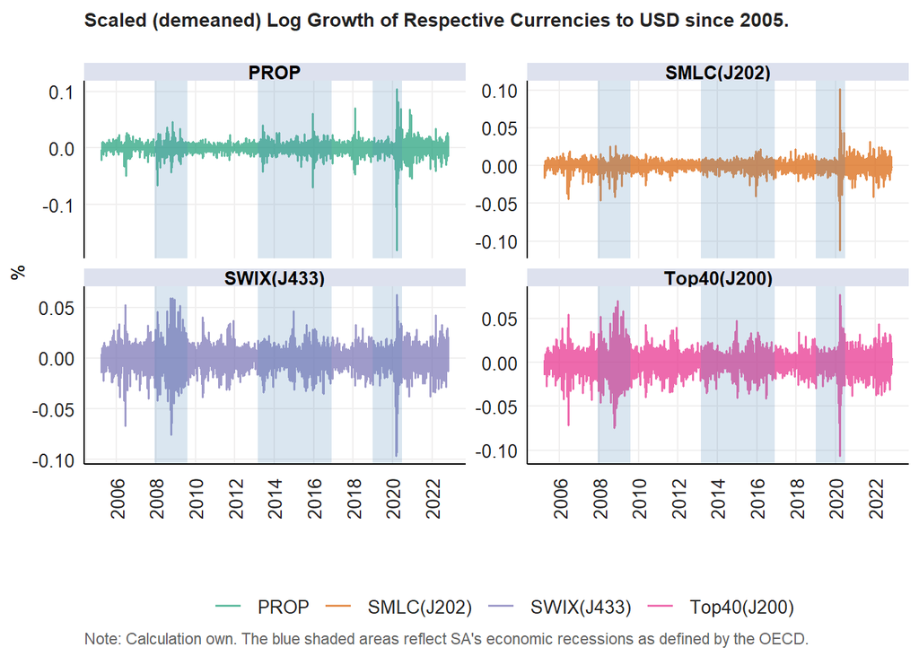

```r
SD_plot_data <- df_DCC |>  arrange(date) |>

    group_by(Index) |>

    mutate(Growth = log(Cum_ret) - lag(log(Cum_ret))) |>

    filter(date > dplyr::first(date)) |>

    mutate(scaledgrowth = Growth - mean(Growth, rm.na = T)) |>     # Scale the Growth by demeaning

    mutate(SampleSD = (sqrt(scaledgrowth^2))) |>

    ungroup()




Scaledgrowth_plot_df <-  SD_plot_data |>

    ggplot() +

  geom_line(aes(date, scaledgrowth , color = Index), size = 0.6, alpha = 0.7) +

    facet_wrap(~Index, scales = "free_y")+





    annotate("rect", xmin = lubridate::ymd("20130301"), xmax = lubridate::ymd("20161201"), ymin = -Inf, ymax = Inf,alpha = .2, fill='steelblue', alpha= 0.05) +

     annotate("rect", xmin = lubridate::ymd("20071201"), xmax = lubridate::ymd("20090801"), ymin = -Inf, ymax = Inf,alpha = .2, fill='steelblue', alpha= 0.05) +
     annotate("rect", xmin = lubridate::ymd("20190101"), xmax = lubridate::ymd("20200701"), ymin = -Inf, ymax = Inf,alpha = .2, fill='steelblue', alpha= 0.05) +

   fmxdat::theme_fmx(title.size = fmxdat::ggpts(30),
                    subtitle.size = fmxdat::ggpts(0),
                    caption.size = fmxdat::ggpts(25),
                    CustomCaption = T) +

  fmxdat::fmx_cols() +

  labs(x = "", y = "%", caption = "Note: Calculation own. The blue shaded areas reflect SA's economic recessions as defined by the OECD.",
       title = "Scaled (demeaned) Log Growth of Respective Currencies to USD since 2005.",
       subtitle = "")

SD_plot <- SD_plot_data |>

  ggplot() +

   geom_line(aes(date, SampleSD , color = Index), size = 0.6, alpha = 0.7) +


    annotate("rect", xmin = lubridate::ymd("20130301"), xmax = lubridate::ymd("20161201"), ymin = -Inf, ymax = Inf,alpha = .2, fill='steelblue', alpha= 0.05) +

     annotate("rect", xmin = lubridate::ymd("20071201"), xmax = lubridate::ymd("20090801"), ymin = -Inf, ymax = Inf,alpha = .2, fill='steelblue', alpha= 0.05) +
     annotate("rect", xmin = lubridate::ymd("20190101"), xmax = lubridate::ymd("20200701"), ymin = -Inf, ymax = Inf,alpha = .2, fill='steelblue', alpha= 0.05) +

    facet_wrap(~Index, scales = "free_y")+

   fmxdat::theme_fmx(title.size = fmxdat::ggpts(30),
                    subtitle.size = fmxdat::ggpts(0),
                    caption.size = fmxdat::ggpts(25),
                    CustomCaption = T) +

  fmxdat::fmx_cols() +

  labs(x = "", y = "%", caption = "Note: Calculation own. The blue shaded areas reflect SA's economic recessions as defined by the OECD.",
       title = "Sample Standard Deviation of Respective Currencies to USD since 2005.",
       subtitle = "")

# Finplot for finishing touches:



fmxdat::finplot(Scaledgrowth_plot_df, x.vert = T, x.date.type = "%Y", x.date.dist = "2 years", darkcol = T)
```

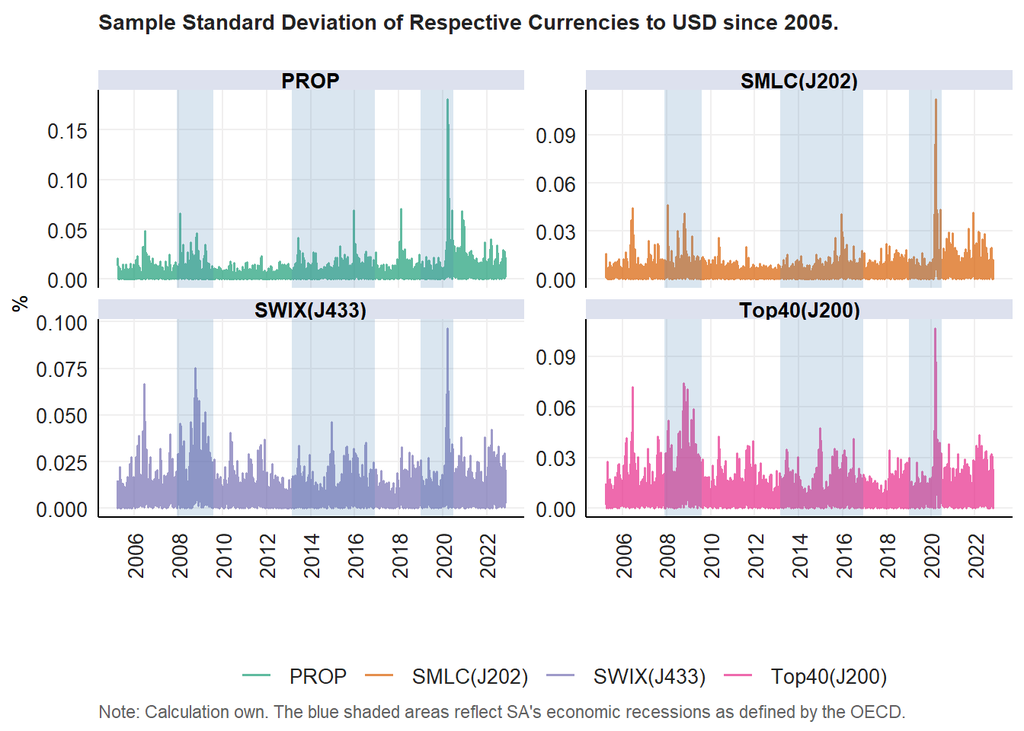

```r
fmxdat::finplot(SD_plot, x.vert = T, x.date.type = "%Y", x.date.dist = "2 years", darkcol = T)
```

The model’s estimated volatility for each index (Figure $\ref{Figure2}$) shows that PROP is the most volatile in comparison to the SMLC(J202) and SWIX(J433) indexes, especially in the past decade, possessing substantially larger jumps in volatility during recessionary periods (blue shaded areas). Moreover, the SMLC(J202) index is the least volatile.

In analysing the estimated dynamic conditional correlations across index pairs (Figure $\ref{Figure3}$), the PROP index exhibits a substantially lower time-varying conditional correlation with the SWIX(J433) index compared to the SMLC(J202) index. However, since 2016, this difference has shrunk marginally. On the other hand, the dynamic conditional correlation between the SMLC(J202) and SWIX(J433) indexes is the highest and the more stable among the three index pairs considered.

## MV Conditional Heteroskedasticity tests

I conduct MV Portmanteau tests using MarchTest from MTS package.

```r
######   ########

gwt1 <- SD_plot_data |> select(date, Index, Growth) |> filter(Index %in% c("SWIX(J433)", "PROP", "SMLC(J202)"))



# Change to xts format


gwt_xts1 <- gwt1 |>

    tbl_xts(cols_to_xts = Growth, spread_by = Index)

# MV Portmanteau tests


MarchTest(gwt_xts1)
```

```
## Q(m) of squared series(LM test):
## Test statistic:  5699.07  p-value:  0
## Rank-based Test:
## Test statistic:  2452.686  p-value:  0
## Q_k(m) of squared series:
## Test statistic:  9682.785  p-value:  0
## Robust Test(5%) :  2047.903  p-value:  0
```

The MARCH test indicates that all the MV portmanteau tests reject the null of no conditional heteroskedasticity, motivating our use of MVGARCH models.

## DCC MV-GARCH MODEL

I decide to use a DCC MVGARCH Model; DCC models offer a simple and more parsimonious means of doing MV-vol modelling. In particular, it relaxes the constraint of a fixed correlation structure (assumed by the CCC model), to allow for estimates of time-varying correlation.

```r
# As in the tut, I select a VAR order of zero for the mean equation, and simply use the mean of each series.
# The mean equation is thus in our case simply: Growth = mean(Growth) + et

# Then, for every series, a standard univariate GARCH(1,1) is run - giving us:
# et and sigmat, which is then used to calculate the standardized resids, zt, which is used in DCC calcs after.

DCCPre <- dccPre(gwt_xts1, include.mean = T, p=0) # Find a nice way to put this in a table
```

```
## Sample mean of the returns:  0.0004078085 0.0005823262 0.0004718333
## Component:  1
## Estimates:  2e-06 0.147346 0.84056
## se.coef  :  0 0.012458 0.011918
## t-value  :  6.47192 11.8278 70.52736
## Component:  2
## Estimates:  2e-06 0.135447 0.83566
## se.coef  :  0 0.014118 0.016533
## t-value  :  5.724064 9.593628 50.54456
## Component:  3
## Estimates:  3e-06 0.099673 0.881356
## se.coef  :  1e-06 0.009429 0.011151
## t-value  :  5.07514 10.57106 79.04112
```

I now have the estimates of volatility for each series. Follow my lead below in changing the output to a usable Xts series for each column in xts_rtn:

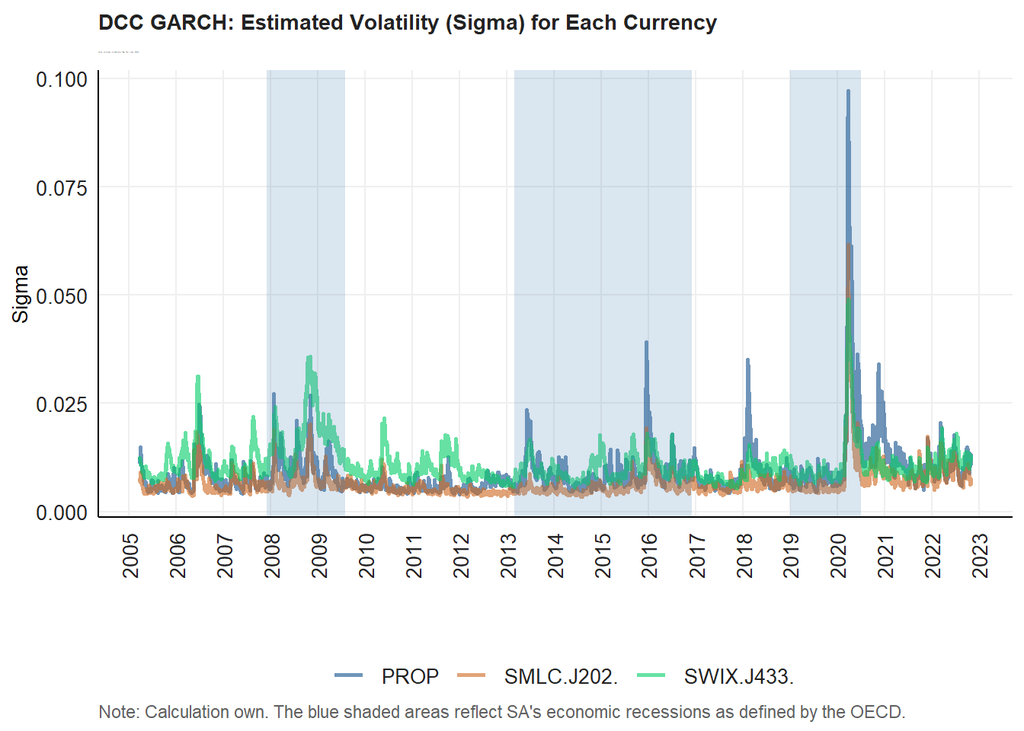

```r
Vol <- DCCPre$marVol

colnames(Vol) <- colnames(gwt_xts1)

Vol <-
  data.frame( cbind( date = index(gwt_xts1), Vol)) |>  # Add date column which dropped away...
  mutate(date = as.Date(date)) |>  tibble::as_tibble()  # make date column a date column...



TidyVol <- Vol |>  pivot_longer(names_to = "Indexes", values_to =  "Sigma", cols =  -date)

TidyVol_plot <- TidyVol |> ggplot() +

  geom_line(aes(date, Sigma , color = Indexes), size = 0.9, alpha = 0.6) +

    annotate("rect", xmin = lubridate::ymd("20130301"), xmax = lubridate::ymd("20161201"), ymin = -Inf, ymax = Inf,alpha = .2, fill='steelblue', alpha= 0.05) +

     annotate("rect", xmin = lubridate::ymd("20071201"), xmax = lubridate::ymd("20090801"), ymin = -Inf, ymax = Inf,alpha = .2, fill='steelblue', alpha= 0.05) +
     annotate("rect", xmin = lubridate::ymd("20190101"), xmax = lubridate::ymd("20200701"), ymin = -Inf, ymax = Inf,alpha = .2, fill='steelblue', alpha= 0.05) +


   fmxdat::theme_fmx(title.size = fmxdat::ggpts(30),
                    subtitle.size = fmxdat::ggpts(0),
                    caption.size = fmxdat::ggpts(25),
                    CustomCaption = T) +

  fmxdat::fmx_cols() +

  labs(x = "", y = "Sigma", caption = "Note: Calculation own. The blue shaded areas reflect SA's economic recessions as defined by the OECD.",
       title = "DCC GARCH: Estimated Volatility (Sigma) for Each Currency",
       subtitle = "Notice this includes the Bloomberg Dollar Spot Index (BBDXY)")

# And finally touches with finplot

fmxdat::finplot(TidyVol_plot, x.vert = T, x.date.type = "%Y", x.date.dist = "1 years", darkcol = F)
```

## Calculating the DCC Model

I will now extract the estimated standardized residuals to calculate the DCC Model.

```r
# The standardized residuals

StdRes <- DCCPre$sresi

# I first do the detach trick from the tut:

pacman::p_load(tidyverse,fmxdat, rmsfuns, tbl2xts, tidyr, ggpubr, broom,rstatix, modelr )

detach("package:tidyverse", unload=TRUE)
detach("package:fmxdat", unload=TRUE)
detach("package:rmsfuns", unload=TRUE)
detach("package:tbl2xts", unload=TRUE)
detach("package:ggpubr", unload=TRUE)
detach("package:rstatix", unload=TRUE)
detach("package:modelr", unload=TRUE)
detach("package:broom", unload=TRUE)
detach("package:tidyr", unload=TRUE)
detach("package:dplyr", unload=TRUE)

DCC <- dccFit(StdRes,type = "Engle")
```

```
## Estimates:  0.9357251 0.02997446 8.69082
## st.errors:  0.01243048 0.004531957 0.4955076
## t-values:   75.27664 6.614021 17.53923
```

```r
pacman::p_load(tidyverse,fmxdat, rmsfuns, tbl2xts, tidyr, ggpubr, broom,rstatix, modelr )
```

```r
Rhot <- DCC$rho.t
# Right, so it gives us all the columns together in the form:
# X1,X1 ; X1,X2 ; X1,X3 ; ....

# So, let's be clever about defining more informative col names.
# I will create a renaming function below:
ReturnSeries = gwt_xts1
DCC.TV.Cor = Rhot

renamingdcc <- function(ReturnSeries, DCC.TV.Cor) {

ncolrtn <- ncol(ReturnSeries)
namesrtn <- colnames(ReturnSeries)
paste(namesrtn, collapse = "_")

nam <- c()
xx <- mapply(rep, times = ncolrtn:1, x = namesrtn)
# Now let's be creative in designing a nested for loop to save the names corresponding to the columns of interest..

# TIP: draw what you want to achieve on a paper first. Then apply code.

# See if you can do this on your own first.. Then check vs my solution:

nam <- c()
for (j in 1:(ncolrtn)) {
for (i in 1:(ncolrtn)) {
  nam[(i + (j-1)*(ncolrtn))] <- paste(xx[[j]][1], xx[[i]][1], sep="_")
}
}

colnames(DCC.TV.Cor) <- nam

# So to plot all the time-varying correlations wrt SBK:
 # First append the date column that has (again) been removed...
DCC.TV.Cor <-
    data.frame( cbind( date = index(ReturnSeries), DCC.TV.Cor)) %>% # Add date column which dropped away...
    mutate(date = as.Date(date)) %>%  tbl_df()

DCC.TV.Cor <- DCC.TV.Cor %>% gather(Pairs, Rho, -date)

DCC.TV.Cor

}

# Let's see if our function works! Excitement!
Rhot <-
  renamingdcc(ReturnSeries = gwt_xts1, DCC.TV.Cor = Rhot)

head(Rhot %>% arrange(date))
```

```
## # A tibble: 6 × 3
##   date       Pairs                   Rho
##   <date>     <chr>                 <dbl>
## 1 2005-03-23 PROP_PROP             1
## 2 2005-03-23 PROP_SMLC.J202.       0.528
## 3 2005-03-23 PROP_SWIX.J433.       0.458
## 4 2005-03-23 SMLC.J202._PROP       0.528
## 5 2005-03-23 SMLC.J202._SMLC.J202. 1
## 6 2005-03-23 SMLC.J202._SWIX.J433. 0.590
```

The figure below points towards heterogeneity in the correlations between the sector pairs over time and reveals that static estimates of comovement (in modeling terms, the Constant Conditional Correlations or CCC) might be misleading.

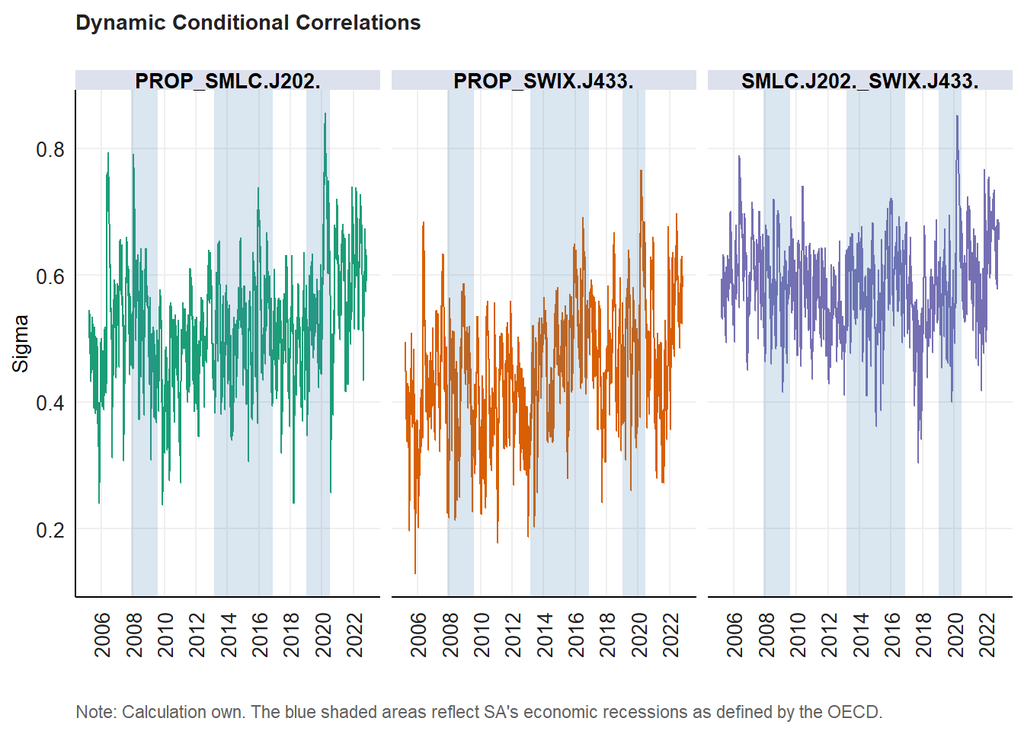

```r
# Let's now create a plot for all the stocks relative to the other stocks...


DCC_plot_PROP <- Rhot|>  filter(!grepl("SWIX.J433._", Pairs ), !grepl("_PROP", Pairs),  !grepl("SMLC.J202._SMLC.J202.", Pairs) ) |>

    ggplot() +

    geom_line(aes(x = date, y = Rho, colour = Pairs),size = 0.4, alpha = 1 ) +


    annotate("rect", xmin = lubridate::ymd("20130301"), xmax = lubridate::ymd("20161201"), ymin = -Inf, ymax = Inf,alpha = .2, fill='steelblue', alpha= 0.05) +

     annotate("rect", xmin = lubridate::ymd("20071201"), xmax = lubridate::ymd("20090801"), ymin = -Inf, ymax = Inf,alpha = .2, fill='steelblue', alpha= 0.05) +
     annotate("rect", xmin = lubridate::ymd("20190101"), xmax = lubridate::ymd("20200701"), ymin = -Inf, ymax = Inf,alpha = .2, fill='steelblue', alpha= 0.05) +

    facet_wrap(~Pairs) +

    fmxdat::theme_fmx(title.size = fmxdat::ggpts(30),
                    subtitle.size = fmxdat::ggpts(0),
                    caption.size = fmxdat::ggpts(25),
                    CustomCaption = T) +

  fmxdat::fmx_cols() +

  labs(x = "", y = "Sigma", caption = "Note: Calculation own. The blue shaded areas reflect SA's economic recessions as defined by the OECD.",
       title = "Dynamic Conditional Correlations",
       subtitle = "")

# And finally touches with finplot

fmxdat::finplot(DCC_plot_PROP, x.vert = T, x.date.type = "%Y", x.date.dist = "2 years", darkcol = T, legend_pos = "none", col.hue = 40)
```

Gather the coefficients $a$ and $b$’s estimates and standard error. From Katzke (2013), indicates that the time-varying correlations are mean reverting since a + b < 1, for three indexes. The coefficient $a$ measures the effect of past standardised innovations on dynamic conditional correlations, while $b$ report the impact of lagged dynamic conditional correlations on the current dynamic conditional correlations (Katzke 2013). In addition to this, the parameters are mostly significant, indicating significant variation over the specified period. More specifically, the statistical significance of a and b indicates that a DCC model vis-a-vis CCC model is more suitable.

```r
xtable(DCCPre$est) # Order is SWIX, SMALLCAP, and PROP
```

```
## % latex table generated in R 4.2.2 by xtable 1.8-4 package
## % Sat Feb  4 10:13:55 2023
## \begin{table}[ht]
## \centering
## \begin{tabular}{rrrr}
##   \hline
##  & omega & alpha1 & beta1 \\
##   \hline
## 1 & 0.00 & 0.15 & 0.84 \\
##   2 & 0.00 & 0.14 & 0.84 \\
##   3 & 0.00 & 0.10 & 0.88 \\
##    \hline
## \end{tabular}
## \end{table}
```

```r
xtable(DCCPre$se.coef)
```

```
## % latex table generated in R 4.2.2 by xtable 1.8-4 package
## % Sat Feb  4 10:13:55 2023
## \begin{table}[ht]
## \centering
## \begin{tabular}{rrrr}
##   \hline
##  & omega & alpha1 & beta1 \\
##   \hline
## 1 & 0.00 & 0.01 & 0.01 \\
##   2 & 0.00 & 0.01 & 0.02 \\
##   3 & 0.00 & 0.01 & 0.01 \\
##    \hline
## \end{tabular}
## \end{table}
```